# Effects of Borrower Characteristics on Borrower APR and Probability of Defaulting on a Loan

## by Sarah Hazem

## Investigation Overview

> In this investigation, I wanted to look at the characteristics of borrowers that could be used to predict their borrower APR and the probability of a borrower defaulting on a loan. To do that, I added an extra "defaulted" binary feature where 1 indicates a customer has defaulted and 0 otherwise. The main focus was on the following characteristics: Prosper Rating, Loan Original Amount and Income Range.

## Dataset Overview

> The Prosper Loan Dataset consists of 113,937 loans with 81 variables for each loan. These variables the aforementioned characteristics in addition to other characteristics like debt to income ratio, loan category, occupation, and more. Over 29,000 entries were removed due to missing values in key characteristics.

## Distribution of Borrower APR

Borrower APR has a very small range of values, from about 0.05 at the lowest to 0.45 at the highest. Plotted on a normal scale, the distribution of Borrower APR takes on a multimodal shape.

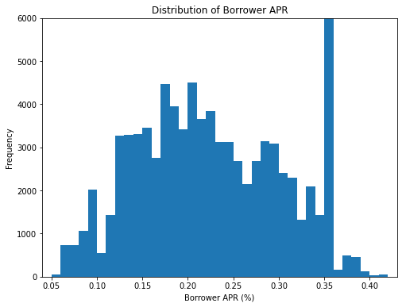

## Distribution of Loan Original Amount

The Loan Original Amount is a variable indicating the original amount given to borrowers. Its values range from 1000 at the lowest to 35000 at the highest. The distribution is right-skewed with most common loan amount at 1000 with several peaks at 10,000, 15,000, and 25,000.

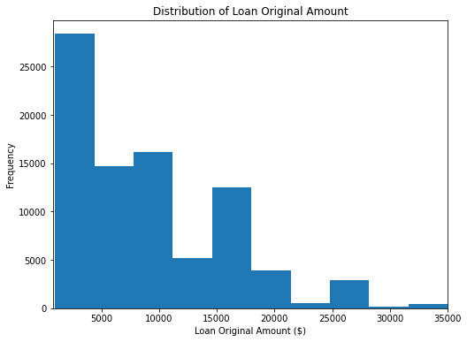

## Borrower APR vs. Loan Original Amount

Plotting price Loan Original Amount vs. Borrower APR produces an approximately negative linear relationship.

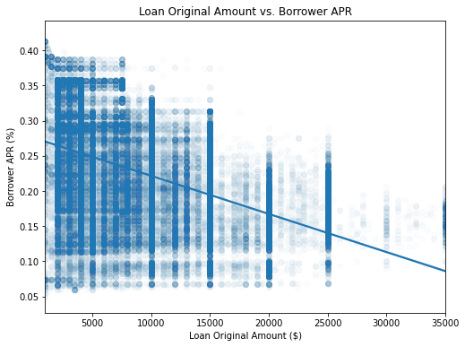

## Borrower APR vs. Prosper Rating

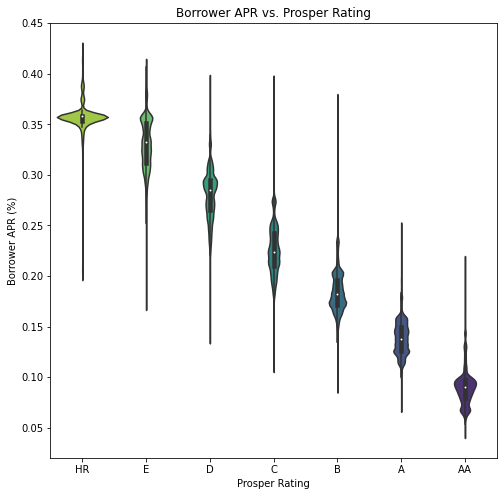

## Borrower APR vs. Income Range

Customers are divided into multiple income ranges with the lowest range at $0 and the highest range at 100,000+. There is a negative relationship between borrower APR and income range with the exception of people who are unemployed or have an income of zero, as the APR decreases gradually as income increases.

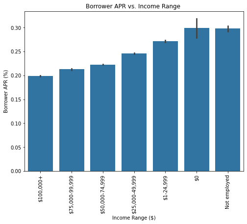

## Percentage of Defaulting vs. Non-Defaulting Customers

Customers have been divided into two categories: defaulted and did not default. The following pie chart shows the percentage of defaulting vs. non defaulting customers.

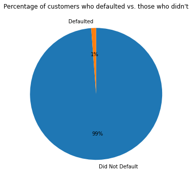

## Percentage of Defaulting by Borrower APR and Loan Original Amount

The negative relationship between borrower APR and Loan Original Amount has already been established. By comparing that to the defaulting rate, we find that customers who defaulted had on average a higher APR and a lower loan original amount.

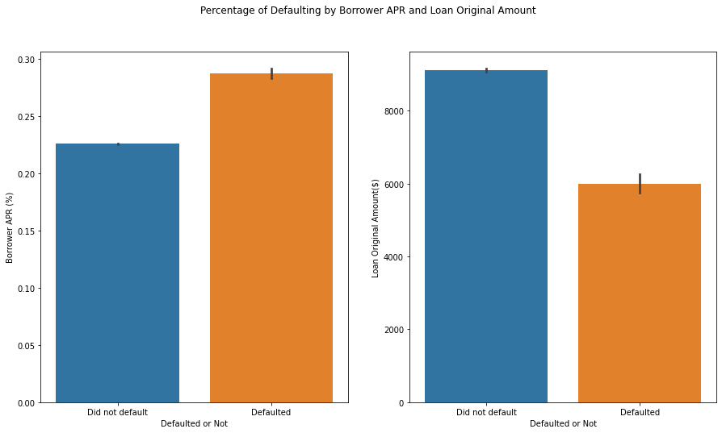

## Percentage of Defaulting by Prosper Rating and Income Range

The most common Prosper Rating for those who defaulted is a rating of D (a middle rating) and the most common Income Range for those who defaulted is an Income of $25,000-$49,999 (a middle income range). This is a very interesting discovery as its counterintuitive to our previous assumption that people with the lowest ratings and income ranges should have a higher rate of defaulting.

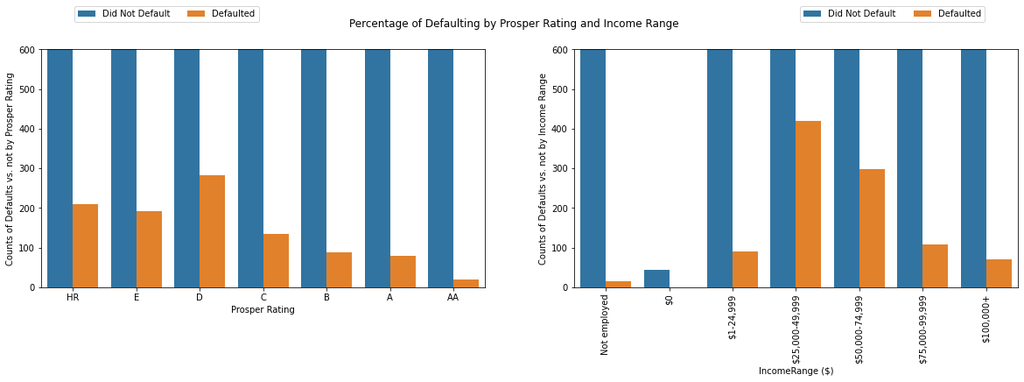

## Borrower APR by Prosper Rating and Defaulting Rate

[figure not shown]

## Borrower APR and Loan Original Amount By Prosper Rating for Customers Who Defaulted

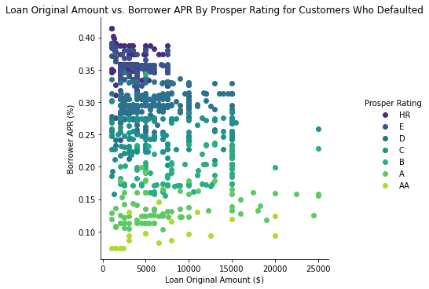